# Chapter 2 Applied Exercises

Caitlyn Ralph

2/8/2018

## Question 8: College.csv

1. `read.csv()` + `rownames()`

```r
college <- read.csv("College.csv", header=T, na.strings="?")
```

```r
rownames(college)=college[,1]
college=college[,-1]
#fix(college)
```

- `summary()`

```r
summary(college)
```

```
##  Private        Apps           Accept          Enroll       Top10perc
##  No :212   Min.   :   81   Min.   :   72   Min.   :  35   Min.   : 1.00
##  Yes:565   1st Qu.:  776   1st Qu.:  604   1st Qu.: 242   1st Qu.:15.00
##            Median : 1558   Median : 1110   Median : 434   Median :23.00
##            Mean   : 3002   Mean   : 2019   Mean   : 780   Mean   :27.56
##            3rd Qu.: 3624   3rd Qu.: 2424   3rd Qu.: 902   3rd Qu.:35.00
##            Max.   :48094   Max.   :26330   Max.   :6392   Max.   :96.00
##    Top25perc      F.Undergrad     P.Undergrad         Outstate
##  Min.   :  9.0   Min.   :  139   Min.   :    1.0   Min.   : 2340
##  1st Qu.: 41.0   1st Qu.:  992   1st Qu.:   95.0   1st Qu.: 7320
##  Median : 54.0   Median : 1707   Median :  353.0   Median : 9990
##  Mean   : 55.8   Mean   : 3700   Mean   :  855.3   Mean   :10441
##  3rd Qu.: 69.0   3rd Qu.: 4005   3rd Qu.:  967.0   3rd Qu.:12925
##  Max.   :100.0   Max.   :31643   Max.   :21836.0   Max.   :21700
##    Room.Board       Books           Personal         PhD
##  Min.   :1780   Min.   :  96.0   Min.   : 250   Min.   :  8.00
##  1st Qu.:3597   1st Qu.: 470.0   1st Qu.: 850   1st Qu.: 62.00
##  Median :4200   Median : 500.0   Median :1200   Median : 75.00
##  Mean   :4358   Mean   : 549.4   Mean   :1341   Mean   : 72.66
##  3rd Qu.:5050   3rd Qu.: 600.0   3rd Qu.:1700   3rd Qu.: 85.00
##  Max.   :8124   Max.   :2340.0   Max.   :6800   Max.   :103.00
##     Terminal       S.F.Ratio      perc.alumni        Expend
##  Min.   : 24.0   Min.   : 2.50   Min.   : 0.00   Min.   : 3186
##  1st Qu.: 71.0   1st Qu.:11.50   1st Qu.:13.00   1st Qu.: 6751
##  Median : 82.0   Median :13.60   Median :21.00   Median : 8377
##  Mean   : 79.7   Mean   :14.09   Mean   :22.74   Mean   : 9660
##  3rd Qu.: 92.0   3rd Qu.:16.50   3rd Qu.:31.00   3rd Qu.:10830
##  Max.   :100.0   Max.   :39.80   Max.   :64.00   Max.   :56233
##    Grad.Rate
##  Min.   : 10.00
##  1st Qu.: 53.00
##  Median : 65.00
##  Mean   : 65.46
##  3rd Qu.: 78.00
##  Max.   :118.00
```

- `pairs()`

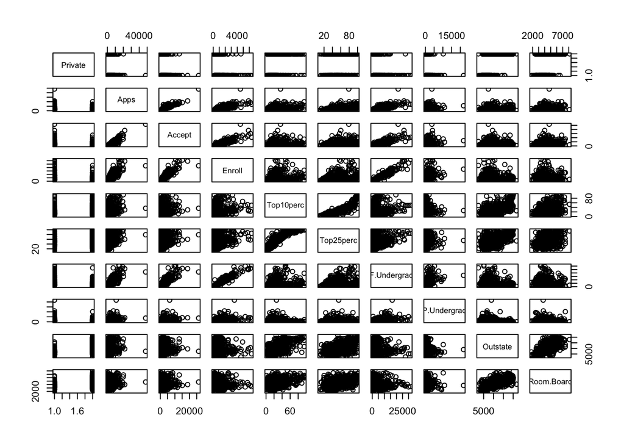

```r
pairs(college[,1:10])
```

- side-by-side box plots

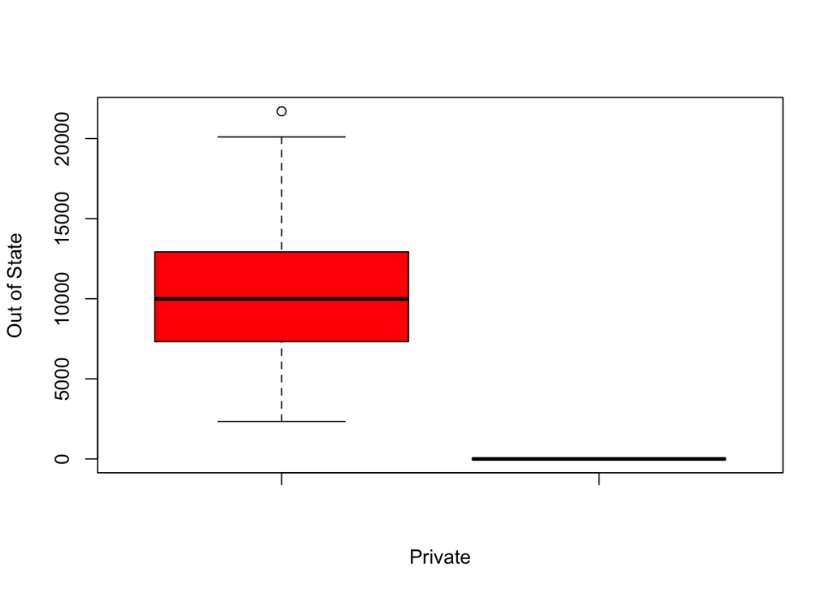

```r
attach(college)
Private=as.factor(Private)
boxplot(Outstate, Private, col="red", varwidth=T, xlab="Private", ylab="Out of State")
```

- binning

```r
Elite=rep("No",nrow(college))
Elite[college$Top10perc > 50]="Yes"
Elite=as.factor(Elite)
college=data.frame(college,Elite)
summary(Elite)
```

```
##  No Yes
## 699  78
```

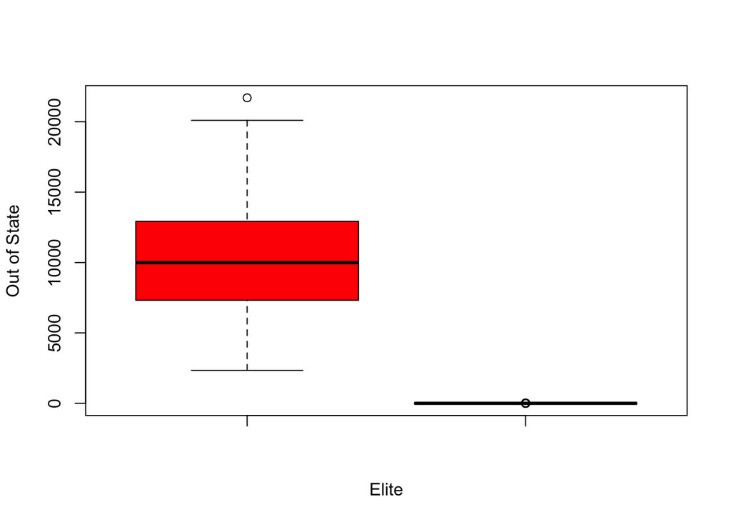

```r
boxplot(Outstate,Elite,col="red",xlab="Elite",ylab="Out of State")
```

- `hist()`

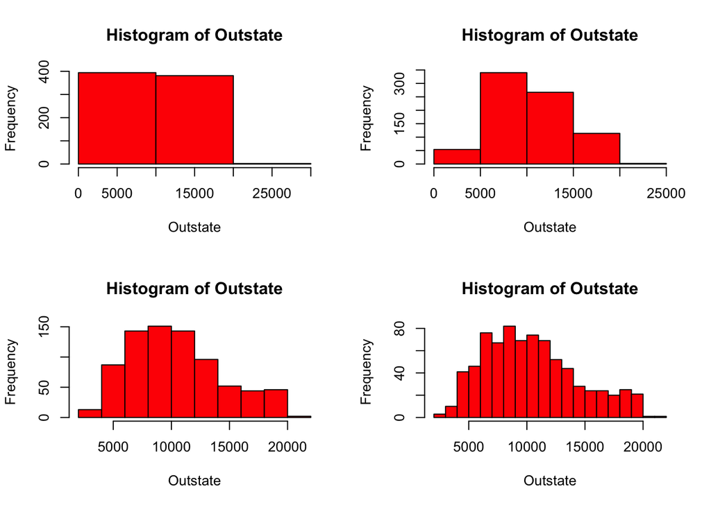

```r
par(mfrow=c(2,2))
hist(Outstate,col="red",breaks=2)
hist(Outstate,col="red",breaks=5)
hist(Outstate,col="red",breaks=10)
hist(Outstate,col="red",breaks=15)
```

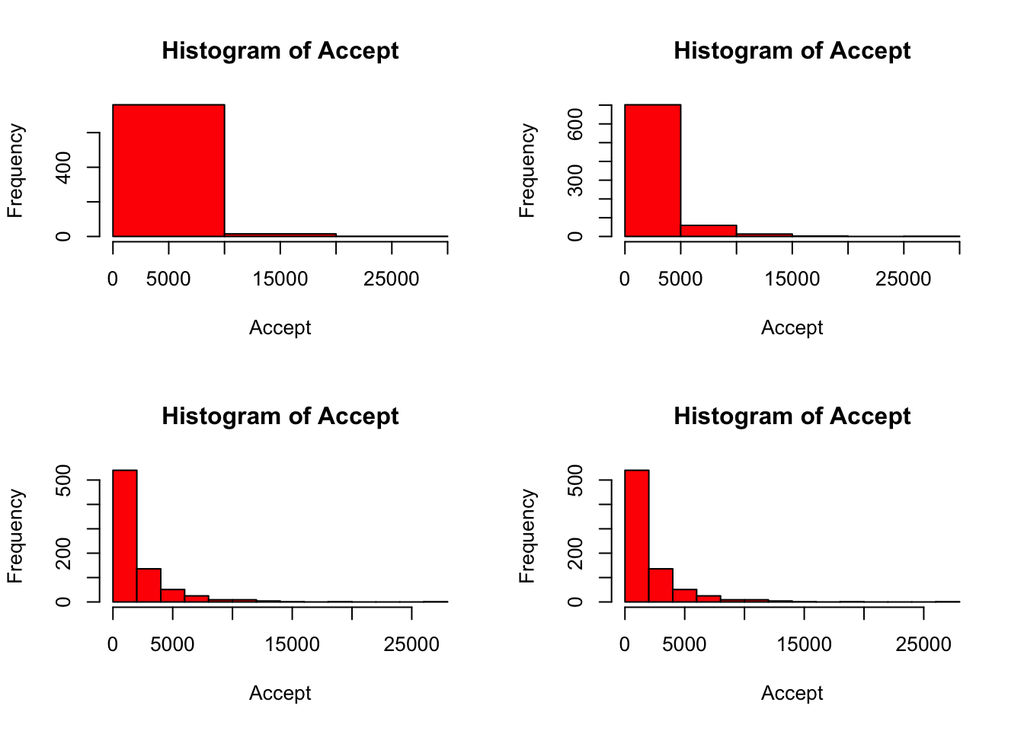

```r
par(mfrow=c(2,2))
hist(Accept,col="red",breaks=2)
hist(Accept,col="red",breaks=5)
hist(Accept,col="red",breaks=10)
hist(Accept,col="red",breaks=15)
```

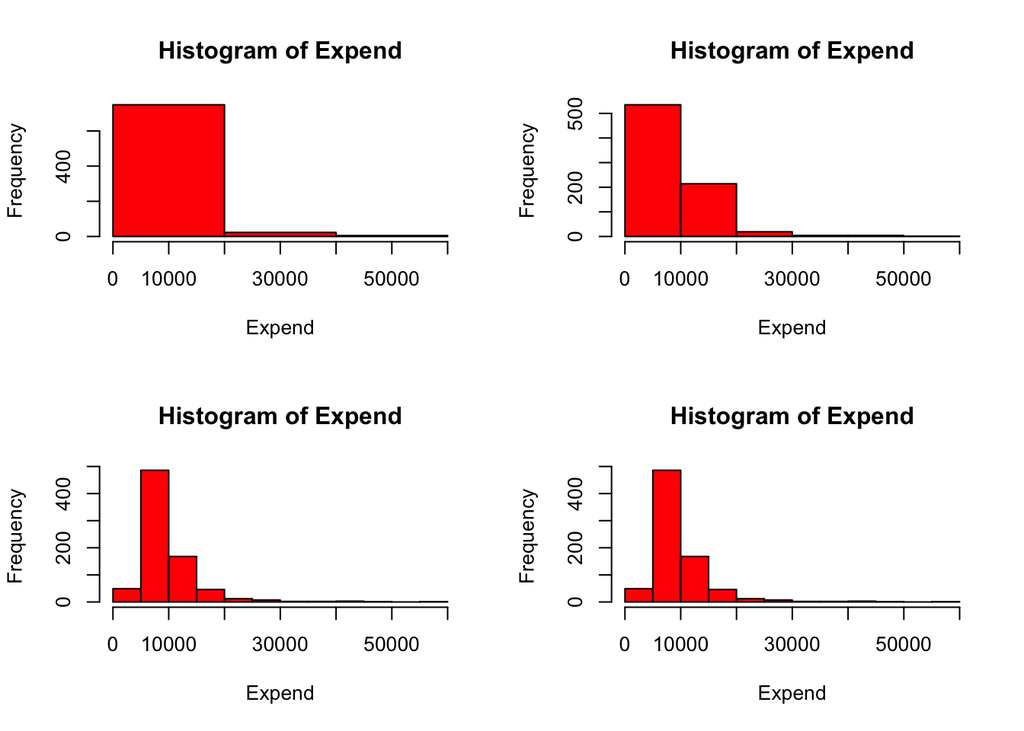

```r
par(mfrow=c(2,2))
hist(Expend,col="red",breaks=2)
hist(Expend,col="red",breaks=5)
hist(Expend,col="red",breaks=10)
hist(Expend,col="red",breaks=15)
```

- exploration

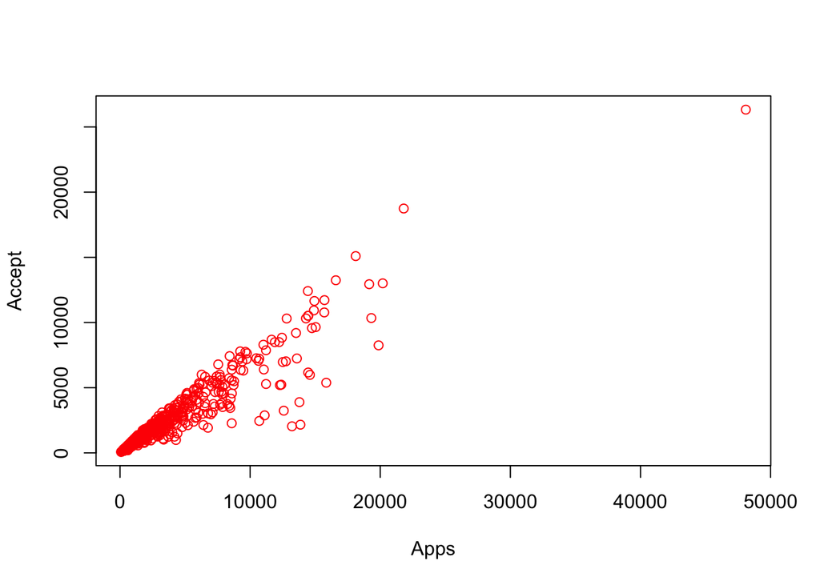

```r
plot(Apps,Accept,col="red")
```

By viewing the scatterplot, there seems to be a positive relationship between the number of applications received and the number of applicants accepted.

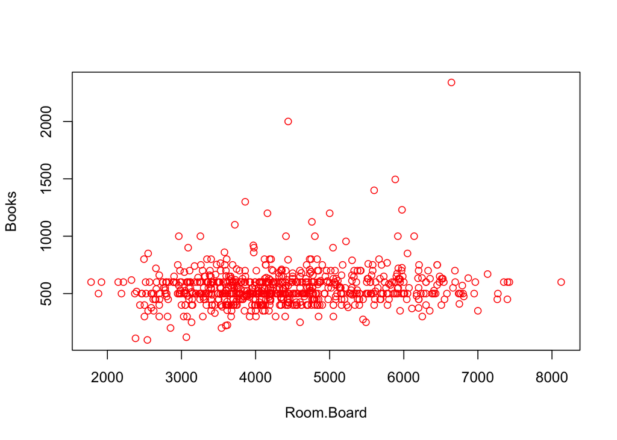

```r
plot(Room.Board,Books,col="red")
```

By viewing the scatterplot, there does not seem to be a relationship between the cost of room & board and the estimated cost of books.

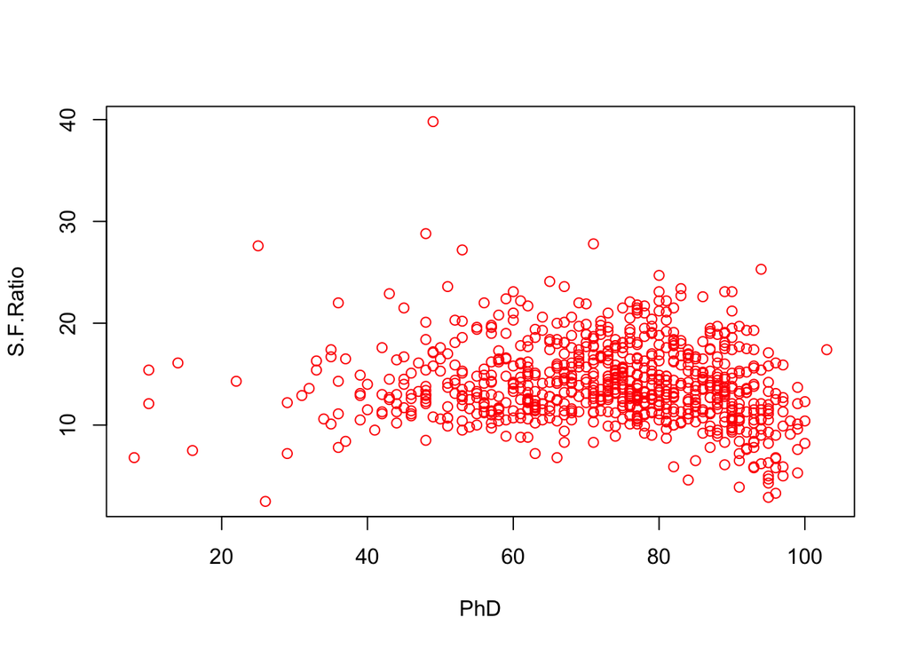

```r
plot(PhD,S.F.Ratio,col="red")
```

By viewing the scatterplot, there does not seem to be a relationship between the percent of faculy with Ph.D.’s and the student/faculty ratio.

## Question 9: Auto data

1. Quanitative vs. qualitative predictors

```r
Auto=read.table("Auto.data.txt",header=T,na.strings="?")
#fix(Auto)
```

Quanitative: mpg, displacement, horsepower, weight, acceleration, year

Qualitative: cylinders, origin, name

2. `range()`

```r
attach(Auto)
range(mpg)
```

```
## [1]  9.0 46.6
```

```r
range(displacement, na.rm=TRUE)
```

```
## [1]  68 455
```

```r
range(horsepower, na.rm=TRUE)
```

```
## [1]  46 230
```

```r
range(weight, na.rm=TRUE)
```

```
## [1] 1613 5140
```

```r
range(acceleration, na.rm=TRUE)
```

```
## [1]  8.0 24.8
```

```r
range(year, na.rm=TRUE)
```

```
## [1] 70 82
```

3. `mean()` and `sd()`

```r
mean(mpg, na.rm=TRUE)
```

```
## [1] 23.51587
```

```r
sd(mpg, na.rm=TRUE)
```

```
## [1] 7.825804
```

```r
mean(displacement, na.rm=TRUE)
```

```
## [1] 193.5327
```

```r
sd(displacement, na.rm=TRUE)
```

```
## [1] 104.3796
```

```r
mean(horsepower, na.rm=TRUE)
```

```
## [1] 104.4694
```

```r
sd(horsepower, na.rm=TRUE)
```

```
## [1] 38.49116
```

```r
mean(weight, na.rm=TRUE)
```

```
## [1] 2970.262
```

```r
sd(weight, na.rm=TRUE)
```

```
## [1] 847.9041
```

```r
mean(acceleration, na.rm=TRUE)
```

```
## [1] 15.55567
```

```r
sd(acceleration, na.rm=TRUE)
```

```
## [1] 2.749995
```

```r
mean(year, na.rm=TRUE)
```

```
## [1] 75.99496
```

```r
sd(year, na.rm=TRUE)
```

```
## [1] 3.690005
```

```r
Auto_rm <- Auto[-c(10:85),]
attach(Auto_rm)
range(mpg)
```

```
## [1] 11.0 46.6
```

```r
range(displacement, na.rm=TRUE)
```

```
## [1]  68 455
```

```r
range(horsepower, na.rm=TRUE)
```

```
## [1]  46 230
```

```r
range(weight, na.rm=TRUE)
```

```
## [1] 1649 4997
```

```r
range(acceleration, na.rm=TRUE)
```

```
## [1]  8.5 24.8
```

```r
range(year, na.rm=TRUE)
```

```
## [1] 70 82
```

```r
mean(mpg, na.rm=TRUE)
```

```
## [1] 24.43863
```

```r
sd(mpg, na.rm=TRUE)
```

```
## [1] 7.908184
```

```r
mean(displacement, na.rm=TRUE)
```

```
## [1] 187.0498
```

```r
sd(displacement, na.rm=TRUE)
```

```
## [1] 99.63539
```

```r
mean(horsepower, na.rm=TRUE)
```

```
## [1] 100.9558
```

```r
sd(horsepower, na.rm=TRUE)
```

```
## [1] 35.89557
```

```r
mean(weight, na.rm=TRUE)
```

```
## [1] 2933.963
```

```r
sd(weight, na.rm=TRUE)
```

```
## [1] 810.6429
```

```r
mean(acceleration, na.rm=TRUE)
```

```
## [1] 15.72305
```

```r
sd(acceleration, na.rm=TRUE)
```

```
## [1] 2.680514
```

```r
mean(year, na.rm=TRUE)
```

```
## [1] 77.15265
```

```r
sd(year, na.rm=TRUE)
```

```
## [1] 3.11123
```

5. exploration

```r
attach(Auto)
```

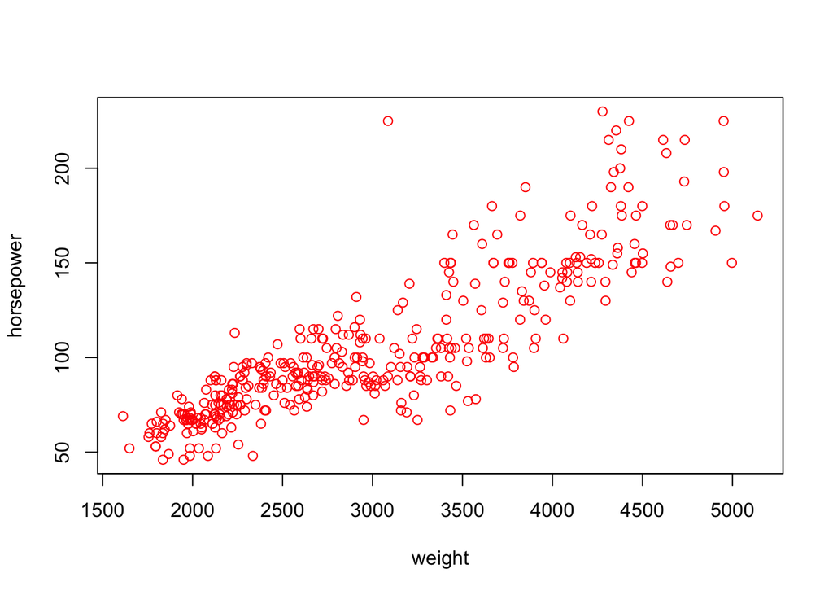

```r
plot(weight,horsepower,col="red")
```

By viewing the scatterplot, there seems to be a positive relationship between weight and horsepower.

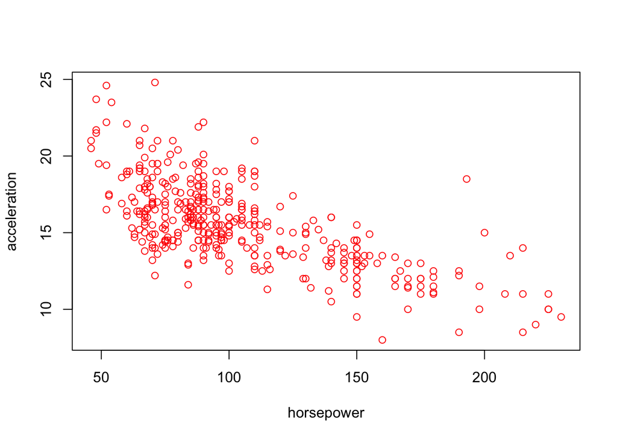

```r
plot(horsepower,acceleration,col="red")
```

By viewing the scatterplot, there seems to be a negative relationship between horsepower and acceleration.

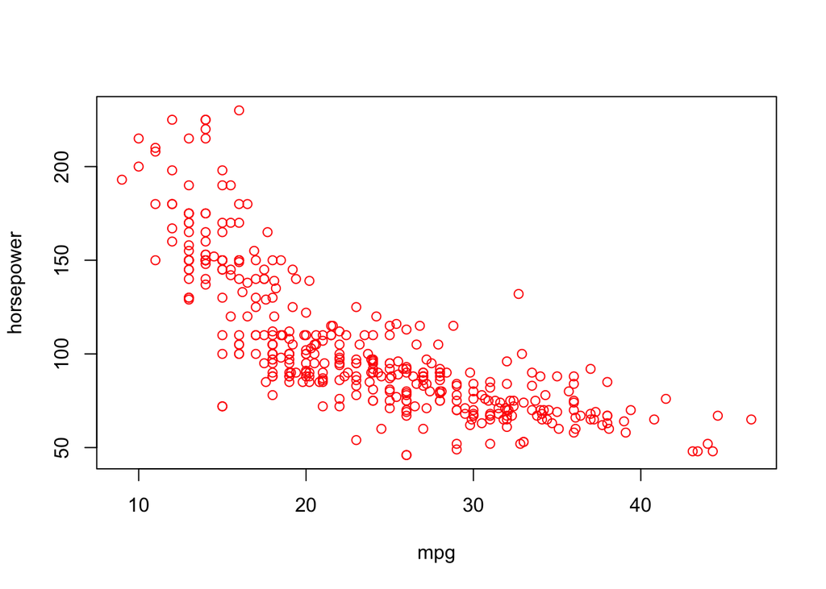

```r
plot(mpg,horsepower,col="red")
```

By viewing the scatterplot, there seems to be a negative relationship between mpg and horsepower.

6. The relationship between mpg and horsepower looks quite strong, so horsepower may be a good predictor for mpg.

## Question 10: Boston housing

```r
library(MASS)
#Boston
dim(Boston)
```

```
## [1] 506  14
```

```r
#fix(Boston)
```

There are 506 rows and 14 columns.

The rows are observations, each being a town. Each column is a variable that may affect the housing value for each town, such at the per capita crime rate by town or the average number of rooms per dwelling.

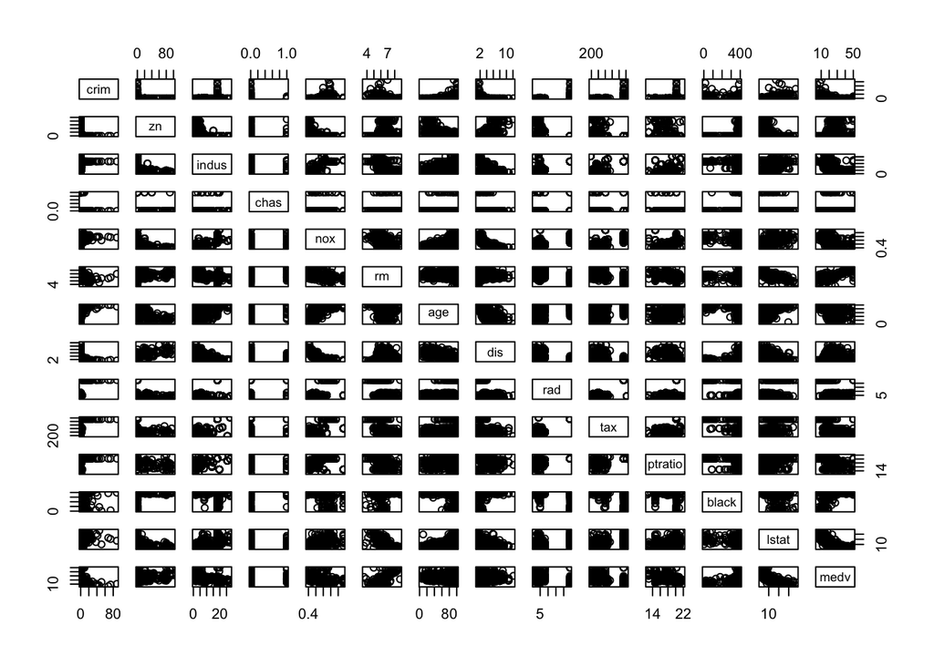

```r
attach(Boston)
pairs(Boston)
```

I don’t see any clear patterns in this format.

There seems there may be a relationship between per capita crime rate and average age, median value of owner-occupied homes, and weighted mean of distances to five Boston employment centers.

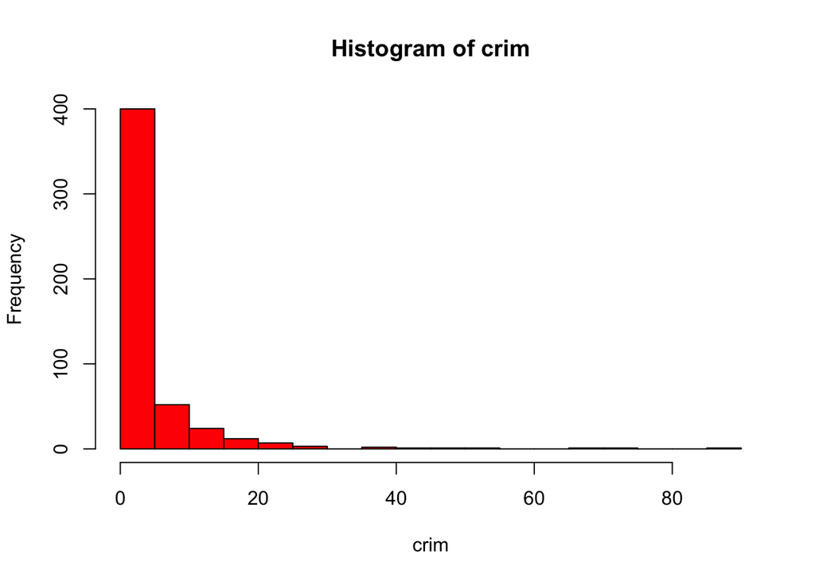

```r
hist(crim,col="red",breaks=15)
```

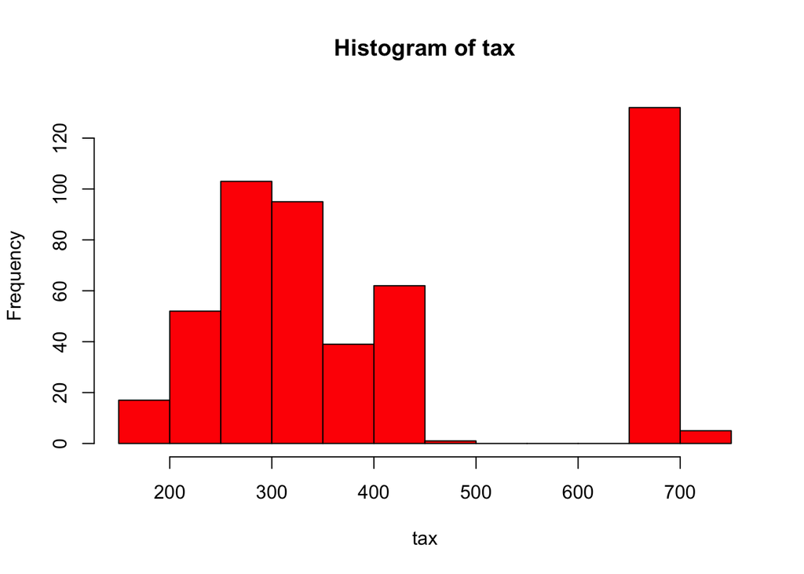

```r
hist(tax,col="red",breaks=15)
```

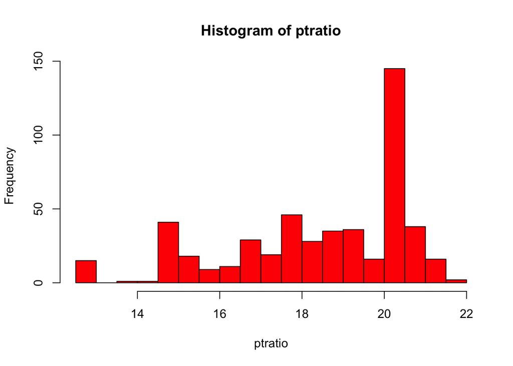

```r
hist(ptratio,col="red",breaks=15)
```

There is a spike in crime rates early in the observations.

The pupil ratio also haa a spike, but it’s farther down in the list of observations.

```r
charles_bound=Boston[chas == 1,]
dim(charles_bound)
```

```
## [1] 35 14
```

```r
median(ptratio)
```

```
## [1] 19.05
```

```r
min(medv)
```

```
## [1] 5
```

```r
min_index = which.min(medv)
min_index
```

```
## [1] 399
```

```r
for (i in 1:ncol(Boston)){
  print(paste(colnames(Boston)[i]))
  print(paste("Value = ",Boston[min_index,i]))
  print(paste("Range = ",range(Boston[,i])))}
```

```
## [1] "crim"
## [1] "Value =  38.3518"
## [1] "Range =  0.00632" "Range =  88.9762"
## [1] "zn"
## [1] "Value =  0"
## [1] "Range =  0"   "Range =  100"
## [1] "indus"
## [1] "Value =  18.1"
## [1] "Range =  0.46"  "Range =  27.74"
## [1] "chas"
## [1] "Value =  0"
## [1] "Range =  0" "Range =  1"
## [1] "nox"
## [1] "Value =  0.693"
## [1] "Range =  0.385" "Range =  0.871"
```

[output cut: 27 more lines]

Value falls in the middle of the crim range, in the middle of indus, in the middle/high-end of nox, in the middle of the rm, is the max of age, on the low-end of dis, on the high-end of tax, on the high-end of ptratio, the max of black, on the high-end of lstat, and minimum of mdev.

```r
seven_rooms=Boston[rm > 7,]
dim(seven_rooms)
```

```
## [1] 64 14
```

```r
eight_rooms=Boston[rm > 8,]
dim(eight_rooms)
```

```
## [1] 13 14
```

```r
eight_rooms
```

```
##        crim zn indus chas    nox    rm  age    dis rad tax ptratio  black
## 98  0.12083  0  2.89    0 0.4450 8.069 76.0 3.4952   2 276    18.0 396.90
## 164 1.51902  0 19.58    1 0.6050 8.375 93.9 2.1620   5 403    14.7 388.45
## 205 0.02009 95  2.68    0 0.4161 8.034 31.9 5.1180   4 224    14.7 390.55
## 225 0.31533  0  6.20    0 0.5040 8.266 78.3 2.8944   8 307    17.4 385.05
## 226 0.52693  0  6.20    0 0.5040 8.725 83.0 2.8944   8 307    17.4 382.00
## 227 0.38214  0  6.20    0 0.5040 8.040 86.5 3.2157   8 307    17.4 387.38
## 233 0.57529  0  6.20    0 0.5070 8.337 73.3 3.8384   8 307    17.4 385.91
## 234 0.33147  0  6.20    0 0.5070 8.247 70.4 3.6519   8 307    17.4 378.95
## 254 0.36894 22  5.86    0 0.4310 8.259  8.4 8.9067   7 330    19.1 396.90
## 258 0.61154 20  3.97    0 0.6470 8.704 86.9 1.8010   5 264    13.0 389.70
## 263 0.52014 20  3.97    0 0.6470 8.398 91.5 2.2885   5 264    13.0 386.86
## 268 0.57834 20  3.97    0 0.5750 8.297 67.0 2.4216   5 264    13.0 384.54
## 365 3.47428  0 18.10    1 0.7180 8.780 82.9 1.9047  24 666    20.2 354.55
##     lstat medv
## 98   4.21 38.7
## 164  3.32 50.0
## 205  2.88 50.0
## 225  4.14 44.8
## 226  4.63 50.0
## 227  3.13 37.6
## 233  2.47 41.7
## 234  3.95 48.3
## 254  3.54 42.8
## 258  5.12 50.0
## 263  5.91 48.8
## 268  7.44 50.0
## 365  5.29 21.9
```